# Indel Signature InsDel_F

# InsDel_F

**Note**

InsDel_F and ID_F are primarily characterized by 2bp deletions arising from short tandem repeats in which the deleted sequence is repeated 1 to 3 times, or from deletions associated with 1bp microhomology. Previous studies have shown that this mutational process depends on TOP1‑mediated cleavage at genome‑embedded ribonucleotides under conditions of RNase H2 deficiency, and has been validated in yeast, human cell lines, and mouse models (Reijns et al., Nature, 2022). In contrast to ID4/C_ID4, which exhibits a broader spectrum of 2–5bp deletions at short tandem repeats, ID_F and InsDel_F are specifically dominated by 2bp deletions and show a strong preference for mutations occurring at CTCT motifs, whereas C_ID4 is preferentially associated with TTTT motifs.

(corresponds to 83-type signature ID_F)

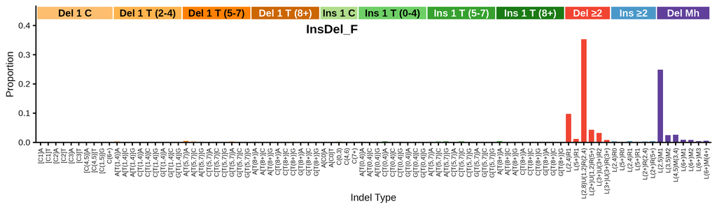

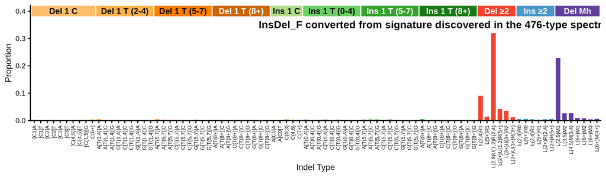

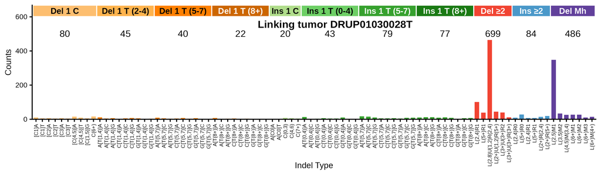

**Click to view decomposition of the linking tumor spectrum**

Partial mutation signature of DRUP01030028T due to InsDel_F

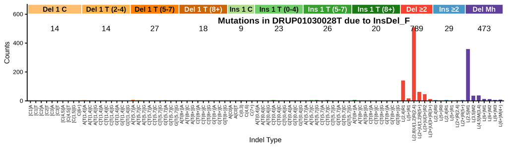

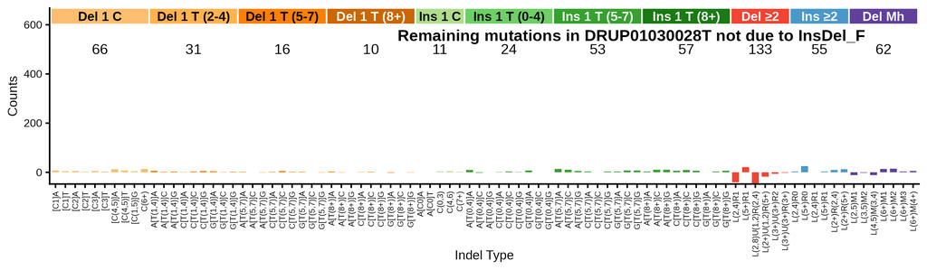

Max neg fraction (maximum allowed negative residual count as fraction of total): 0.09  
N subtract (mutation count assigned to signature): 1441.9  
N residual (mutation count in residual “partial spectrum”): 233.1  
Total negative (sum of negative residual mutation counts): 142.3  
N negative channels (number of channels with negative residual): 16  
P(≥ total negative) (Monte Carlo estimated probability that negative-binomial-sampled spectra from the signature contributing N subtract mutations would produce a total negative count >= the observed Total negative; higher number means not surprising): 0.566

**Per-channel residual breakdown**

| Channel | Spectrum | Sig_Count | Residual | Sig_Prop |
| --- | --- | --- | --- | --- |
| [Del(C):R1]A | 10 | 2.7 | 7.3 | 0.00185 |
| [Del(C):R1]T | 5 | 0.7 | 4.3 | 0.00051 |
| [Del(C):R2]A | 6 | 0.8 | 5.2 | 0.00054 |
| [Del(C):R2]T | 4 | 1.9 | 2.1 | 0.00133 |
| [Del(C):R3]A | 6 | 0.9 | 5.1 | 0.00063 |
| [Del(C):R3]T | 4 | 0.4 | 3.6 | 0.00027 |
| [Del(C):R(4,5)]A | 15 | 1.9 | 13.1 | 0.00130 |
| [Del(C):R(4,5)]T | 9 | 1.7 | 7.3 | 0.00119 |
| [Del(C):R(1,5)]G | 5 | 0.9 | 4.1 | 0.00061 |
| Del(C):R(6,9) | 16 | 2.6 | 13.4 | 0.00181 |
| A[Del(T):R(1,4)]A | 11 | 4.6 | 6.4 | 0.00321 |
| A[Del(T):R(1,4)]C | 4 | 1.4 | 2.6 | 0.00097 |
| A[Del(T):R(1,4)]G | 6 | 2.8 | 3.2 | 0.00195 |
| C[Del(T):R(1,4)]A | 2 | 0.5 | 1.5 | 0.00035 |
| C[Del(T):R(1,4)]C | 5 | 1.7 | 3.3 | 0.00118 |
| C[Del(T):R(1,4)]G | 7 | 1.2 | 5.8 | 0.00080 |
| G[Del(T):R(1,4)]A | 5 | 0.5 | 4.5 | 0.00034 |
| G[Del(T):R(1,4)]C | 2 | 0.4 | 1.6 | 0.00028 |
| G[Del(T):R(1,4)]G | 3 | 0.5 | 2.5 | 0.00038 |
| A[Del(T):R(5,7)]A | 9 | 7.1 | 1.9 | 0.00492 |
| A[Del(T):R(5,7)]C | 5 | 4.6 | 0.4 | 0.00317 |
| A[Del(T):R(5,7)]G | 3 | 3.6 | -0.6 | 0.00246 |
| C[Del(T):R(5,7)]A | 4 | 1.6 | 2.4 | 0.00109 |
| C[Del(T):R(5,7)]C | 7 | 2.0 | 5 | 0.00141 |
| C[Del(T):R(5,7)]G | 3 | 0.7 | 2.3 | 0.00049 |
| G[Del(T):R(5,7)]A | 6 | 4.2 | 1.8 | 0.00293 |
| G[Del(T):R(5,7)]C | 1 | 0.5 | 0.5 | 0.00034 |
| G[Del(T):R(5,7)]G | 2 | 2.9 | -0.9 | 0.00198 |
| A[Del(T):R(8,)]A | 7 | 3.7 | 3.3 | 0.00255 |
| A[Del(T):R(8,)]C | 2 | 2.5 | -0.5 | 0.00172 |

[output cut: 59 more lines]

## 476-type representations corresponding to InsDel_F

Extracted 476-type signature corresponding to InsDel_F

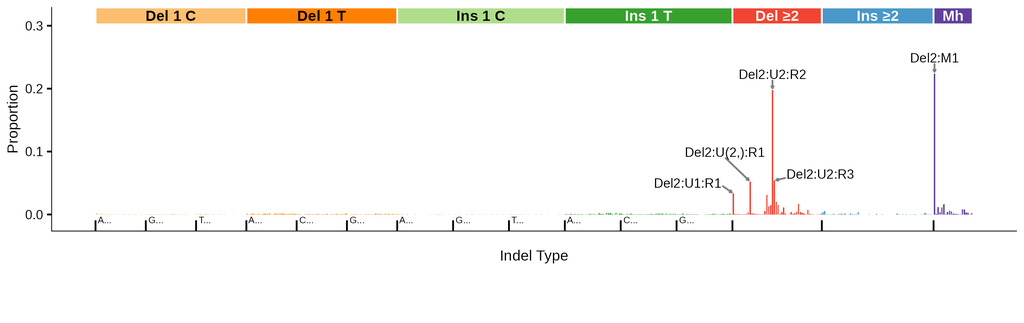

476-type spectrum of the linking tumor DRUP01030028T; cosine similarity to the extracted 476-type signature is 0.9899

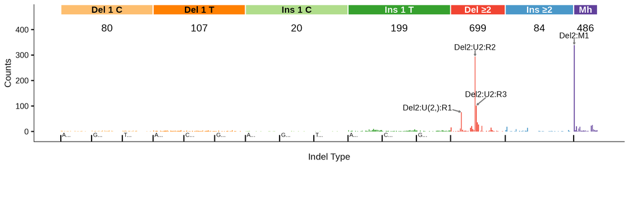

## 83-type signature corresponding to InsDel_F (ID_F)

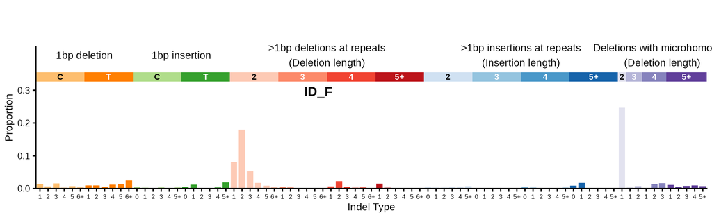

83-type signature converted from signature discovered in the 476-type spectra (using bipartite matching optimization) | cosine similarity to ID_F: 0.9925

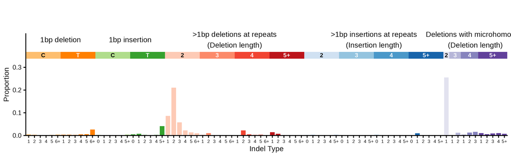

**Click to see flow diagrams: 476-type to 83-type collapse**

These Sankey diagrams show how the 476-type mutation categories are redistributed to 83-type categories using bipartite matching. We only show the diagrams for insertions or deletions of > 1 base because it is for these indels that 476-type categories map to > 1 83-type category.

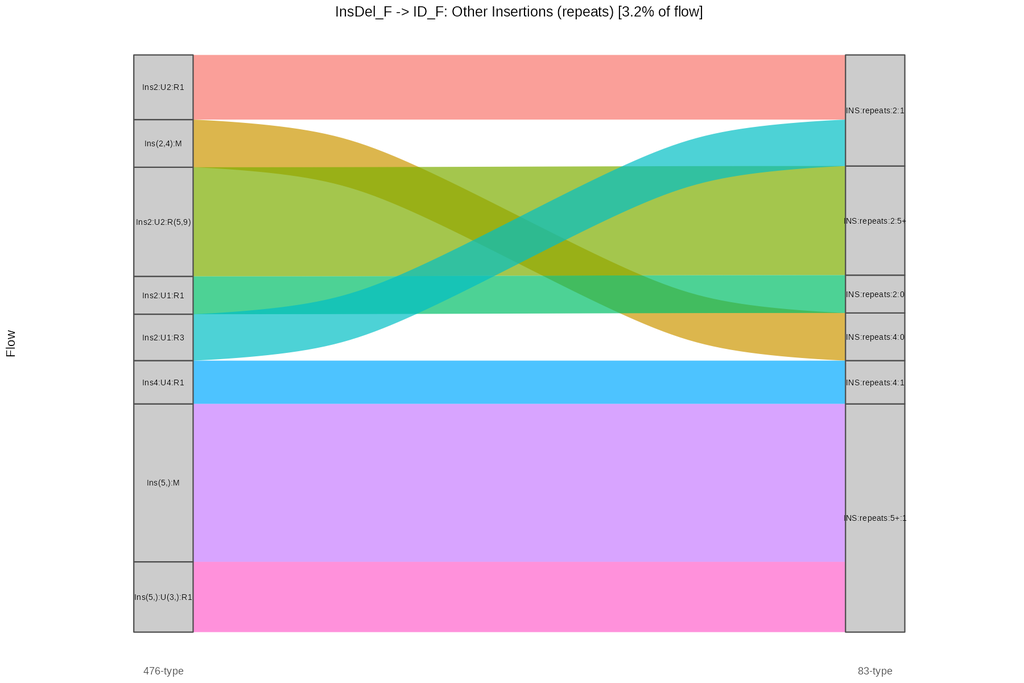

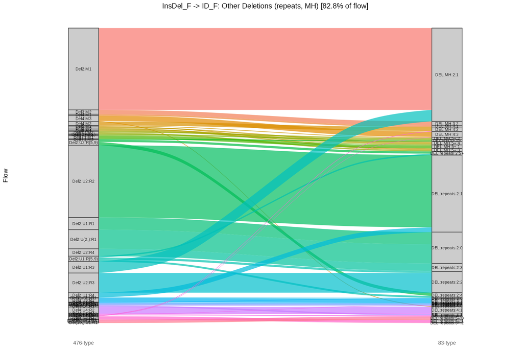

83-type spectrum of the linking tumor DRUP01030028T | cosine similarity to ID_F: 0.9592

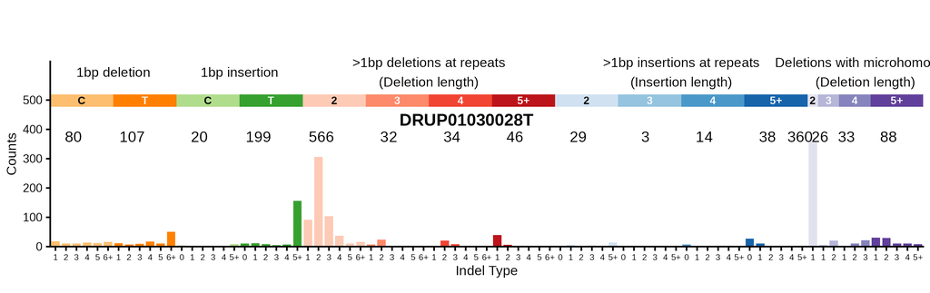

83-type spectrum of best 83-type matching tumor SP5559 | cosine similarity to ID_F: 0.9683

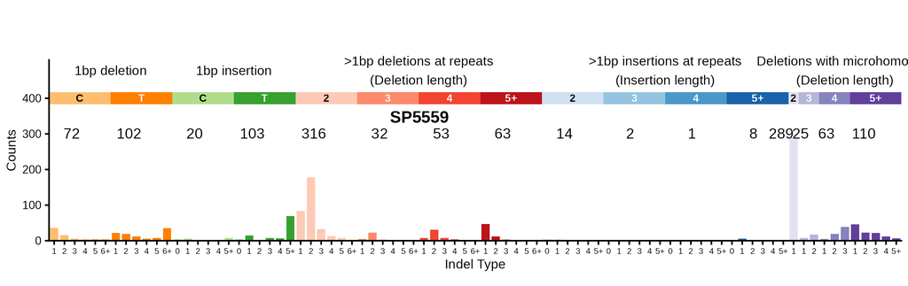

### Similar signatures from Jin et al. 2024

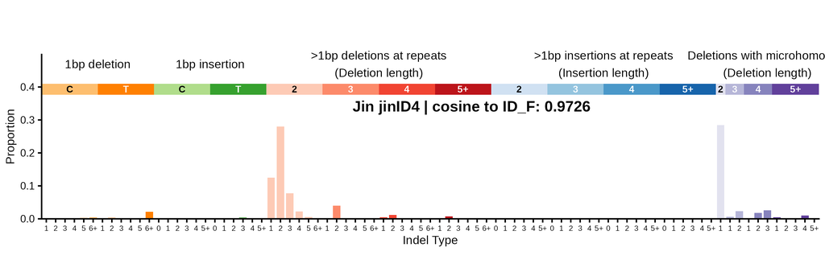